# MINI-PROJECT 5

Dijone Mehmeti

4/26/2022

```r
library(tidyverse)
```

```r
library(maps)
library(mapdata)
library(leaflet)
library(leaflet.extras)
library(leaflet.providers)
library(ggthemes)
```

Below I have included my Mini-Project 3, the initial one

```r
police_data <- read_csv("https://raw.githubusercontent.com/jmzobitz/DST234Datasets/master/police_data_2021.csv")
neighborhood_data <- read_csv("https://raw.githubusercontent.com/jmzobitz/DST234Datasets/master/neighborhood_data_2021.csv")
```

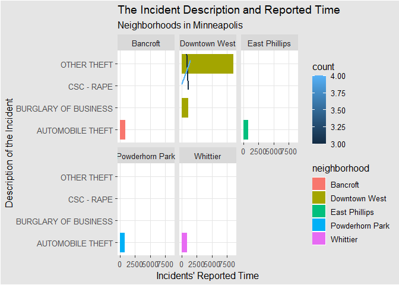

```r
#names(police_data)
#names(neighborhood_data)

police_data %>%
  select(neighborhood, reportedTime, description)%>%
  filter(reportedTime <= 1500)%>%
  group_by(neighborhood, reportedTime, description)%>%
  summarize(count = n())%>%
  arrange(desc(count))%>%
  head(15)%>%
  inner_join(neighborhood_data, by = c("neighborhood" = "Neighborhood"))%>%
  ggplot(aes(x = reportedTime, y = description)) + geom_bar(aes(fill = neighborhood), stat = "identity") + geom_smooth(method = "lm", se = FALSE, aes(group = count, color = count)) + facet_wrap(~ neighborhood) + theme_igray() + labs(x = "Incidents' Reported Time", y = "Description of the Incident", title = "The Incident Description and Reported Time", subtitle = "Neighborhoods in Minneapolis")
```

Provide an explanation of the reasons for revising your data graphic.

- The reason why I wanted to revise my Mini-Project 3 is because I think that project would match perfectly with the map stuff we have learned after. The project contained information about the neighborhoods in Minneapolis and about the crime rates, the type of crimes and I thought I could make the project look different if I incorporated maps into it. I wanted to use the leaflet properties we learned with the circles, markers, and other pop-up features to include that other information about the neighborhoods such as the total population, the incident description and the reported Time. One variable I didn’t include is the count because I don’t think it would make a difference or provide any important information when shown on the map. I still provided the table I got from the Mini-Project 3 with the inner join of the police and neighborhood data to show where I got the information that is shown about the reported crimes, population and so on. However, the actual map is separate from the table since I wanted to separate what I actually revised and what I used from the previous project. I hope that is what you were looking for, and I enjoyed working with maps a lot.

```r
police_data %>%
  select(neighborhood, reportedTime, description)%>%
  filter(reportedTime <= 1500)%>%
  group_by(neighborhood, reportedTime, description)%>%
  summarize(count = n())%>%
  arrange(desc(count))%>%
  head(15)%>%
  inner_join(neighborhood_data, by = c("neighborhood" = "Neighborhood"))
```

```
## # A tibble: 14 x 476
## # Groups:   neighborhood, reportedTime [14]
##    neighborhood reportedTime description count `Total populati~ `Total populati~
##    <chr>               <dbl> <chr>       <int>            <dbl>            <dbl>
##  1 Downtown We~         1200 OTHER THEFT     5             8591              535
##  2 East Philli~          800 AUTOMOBILE~     5             4656              642
##  3 Downtown We~            0 CSC - RAPE      4             8591              535
##  4 Downtown We~          959 OTHER THEFT     4             8591              535
##  5 Downtown We~         1237 OTHER THEFT     4             8591              535
##  6 Downtown We~         1441 OTHER THEFT     4             8591              535
##  7 Powderhorn ~          800 AUTOMOBILE~     4             9858              730
##  8 Whittier              900 AUTOMOBILE~     4            14115              702
##  9 Bancroft              900 AUTOMOBILE~     3             3523              263
## 10 Downtown We~          822 OTHER THEFT     3             8591              535
## 11 Downtown We~          922 OTHER THEFT     3             8591              535
## 12 Downtown We~          958 OTHER THEFT     3             8591              535
## 13 Downtown We~         1033 OTHER THEFT     3             8591              535
## 14 Downtown We~         1100 BURGLARY O~     3             8591              535
## # ... with 470 more variables: Total population - Share <dbl>,
## #   Total population - Margin of Error <dbl>, Male <dbl>,
## #   Male - Share - Margin of Error <dbl>, Male - Share <dbl>,
## #   Male - Margin of Error <dbl>, Female <dbl>,
## #   Female - Share - Margin of Error <dbl>, Female - Share <dbl>,
## #   Female - Margin of Error <dbl>, Under 5 years <dbl>,
## #   Under 5 years - Share - Margin of Error <dbl>, ...
```

[output not shown]

```r
msp_data <- tibble(lat = c( 44.9281, 44.9742, 44.9604, 44.9555, 44.9398),
                   lon = c( -93.2505,-93.2733, -93.2486, -93.2797, -93.2533),
                   place = c("Bancroft","Downtown West", "East Phillips", "Whittier", "Powderhorn Park"),
                   description = c("Automobile Theft","Other Theft, Burglary of Business", "Automobile Theft", "Automobile Theft", "Automobile Theft"),
                   reportedTime = c("900", "8572, 1100", "800", "900", "800"),
                   totalPopulation = c("3523", "8591", "4656", "14115", "9858"),
                   place_color = c("orange", "red", "blue", "green", "yellow"))


msp_data %>%
  leaflet() %>%
  addTiles() %>%
  addMarkers(lng = ~lon,
             lat = ~lat) %>%
  addCircles(lng = ~lon,
             lat = ~lat,
             popup=~place,
             radius = 500,
             color = ~place_color)%>%
  addCircleMarkers(
                   popup=~paste("Neighborhood: ", place, "</br> Incidents: ", description, "</br> Reported Time: ", reportedTime, "</br> Total Population: ", totalPopulation),
                   radius = 5)
```

```
## Assuming "lon" and "lat" are longitude and latitude, respectively
```

[interactive chart not shown]